# Support Vector Machine Classification with Boruta Feature Selection for Detecting Adulteration in Ground Coffee: Raw Spectra

## Run Boruta Algorithm for Optimum Wavelength Selection

```r
  # Set seed for reproducibility
  set.seed(123)

  # Set the dataset name dynamically
  dataset_name <- "raw"

  # Define paths for the execution flag and Boruta result
  flag_file <- paste0("boruta_executed_flag_", dataset_name, ".RData")
  result_file <- paste0("boruta_result_", dataset_name, ".RData")

  # Register cluster for caret to train the models in parallel
  cl <- makeCluster(6, type = "SOCK")
  suppressWarnings(suppressMessages(registerDoSNOW(cl)))

if (!file.exists(result_file)) {
  message(paste("Starting Boruta execution for dataset:", dataset_name))

  # Start the timer
  start_time <- Sys.time()

  # Run Boruta on the train dataset
  boruta_result <- Boruta(formula = binary_class ~ .,
                        data = train_data,
                        doTrace = 2,
                        maxRuns = 100)

  # Stop the cluster
  stopCluster(cl)

  # Register end time
  end_time <- Sys.time()
  print(paste('Time to run the Boruta model:', end_time - start_time))

  # Save Boruta results and execution flag
  boruta_executed <- TRUE
  save(boruta_executed, file = flag_file)
  save(boruta_result, file = result_file)


  message(paste("Boruta execution completed for dataset:", dataset_name, "and results saved."))

} else {
  # Load previously saved results
  message(paste("Result file found. Loading saved Boruta results for dataset:", dataset_name))
  load(result_file)
  load(flag_file)
  message(paste("Boruta already executed for dataset:", dataset_name))
}
```

```
Result file found. Loading saved Boruta results for dataset: raw
```

```
Boruta already executed for dataset: raw
```

```r
# Print Boruta summary
print(boruta_result)
```

```
Boruta performed 99 iterations in 55.84327 secs.
 30 attributes confirmed important: X1386.079956, X1389.609985,
X1393.140015, X1396.670044, X1400.199951 and 25 more;
 150 attributes confirmed unimportant: X1001.369995, X1004.830017,
X1011.77002, X1015.23999, X1018.710022 and 145 more;
 44 tentative attributes left: X1008.299988, X1032.589966, X1336.73999,
X1343.780029, X1347.300049 and 39 more;
```

```r
# Get selected features
final_features <- getSelectedAttributes(boruta_result, withTentative = FALSE)
final_features
```

```
 [1] "X935.609985"  "X939.059998"  "X1386.079956" "X1389.609985" "X1393.140015"
 [6] "X1396.670044" "X1400.199951" "X1403.72998"  "X1407.26001"  "X1410.790039"
[11] "X1414.319946" "X1417.859985" "X1421.390015" "X1424.920044" "X1428.459961"
[16] "X1431.98999"  "X1663"        "X1666.569946" "X1670.140015" "X1673.719971"
[21] "X1677.290039" "X1680.869995" "X1684.439941" "X1688.02002"  "X1691.589966"
[26] "X1695.170044" "X1698.75"     "X1713.069946" "X1716.650024" "X1720.22998"
```

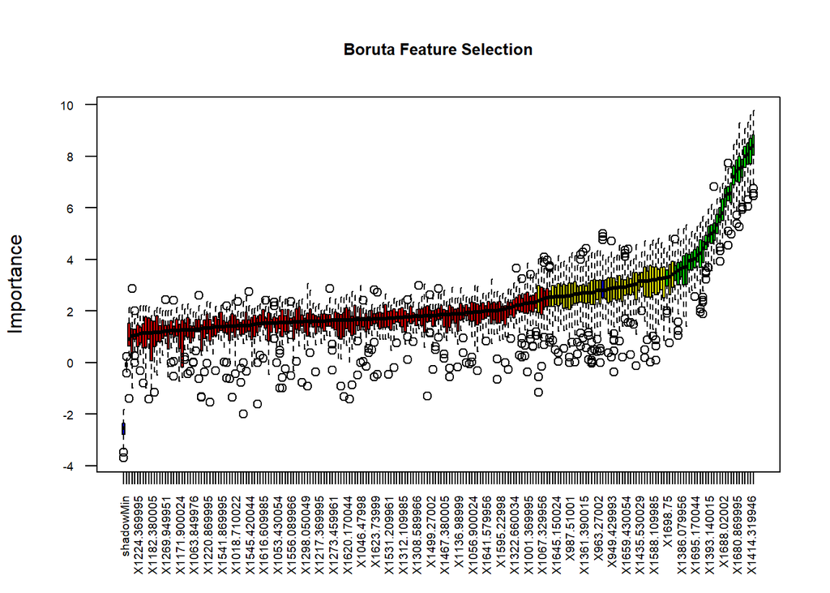

```r
# Plot Boruta results
plot(boruta_result, xlab = "", las = 2,
     cex.main = 0.8, cex.axis = 0.6,
     main = paste("Boruta Feature Selection"))
```

```r
print(paste('The number of selected variables are', length(final_features)))
```

```
[1] "The number of selected variables are 30"
```

## Create a Data frame with the Selected Features

```r
# Subset the training and test data using the selected features
X_train_selected <- X_train[, final_features, drop = FALSE]
X_test_selected <- X_test[, final_features, drop = FALSE]

# Keep y_train and y_test as-is
y_train_selected <- y_train
y_test_selected <- y_test


#Merge data_frame
train_merged <- cbind(X_train_selected, binary_class = y_train_selected)
test_merged <- cbind(X_test_selected, binary_class = y_test_selected)

dim(train_merged)
```

```
[1] 1055   31
```

```r
dim(test_merged)
```

```
[1] 414  31
```

```r
table(train_merged$binary_class)
```

```
 adulterated pure_arabica
        1007           48
```

```r
table(test_merged$binary_class)
```

```
 adulterated pure_arabica
         387           27
```

## Create a Data frame with the Selected Features for SMOTE Data

```r
X_train_selected_smote <- X_train_smote[,final_features, drop = FALSE]
X_test_selected_smote <- X_test[, final_features, drop = FALSE]

# Keep y_train and y_test as-is
y_train_selected_smote <- y_train
y_test_selected_smote <- y_test

#Merge data_frame
train_merged_smote <- cbind(X_train_selected_smote, binary_class = smote_data$binary_class)
test_merged_smote <- cbind(X_test_selected_smote, binary_class = y_test_selected_smote)

dim(train_merged_smote)
```

```
[1] 1872   31
```

```r
dim(test_merged_smote)
```

```
[1] 414  31
```

```r
table(train_merged_smote$binary_class)
```

```
 adulterated pure_arabica
         912          960
```

```r
table(test_merged_smote$binary_class)
```

```
 adulterated pure_arabica
         387           27
```

## Check correlations by HeatMaps

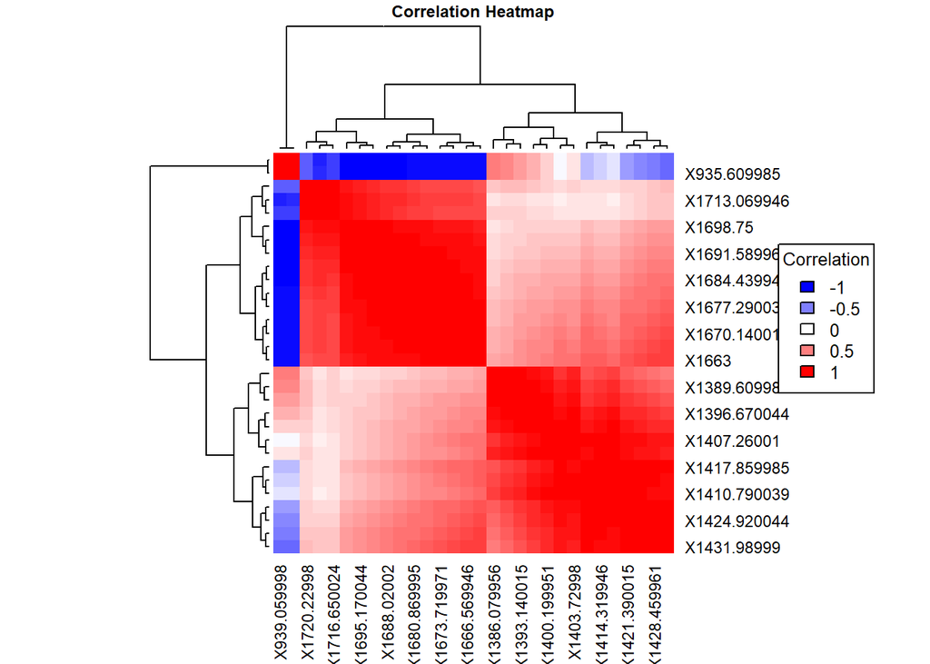

```r
n_features <- length(final_features)

# Calculate the correlation matrix

#Imbalanced Data

#Calculate correlations
corr <- cor(train_merged[, -(n_features+1)])

# Create a heat map
par(cex.main = 0.6)
heatmap(corr, symm = TRUE,
        col = colorRampPalette(c("blue", "white", "red"))(50),
        main = "Correlation Heatmap")

# Add legend

legend("right",
       legend = seq(-1, 1, by = 0.5),  # Correlation range
       fill = colorRampPalette(c("blue", "white", "red"))(5),
       title = "Correlation", cex = 0.8)
```

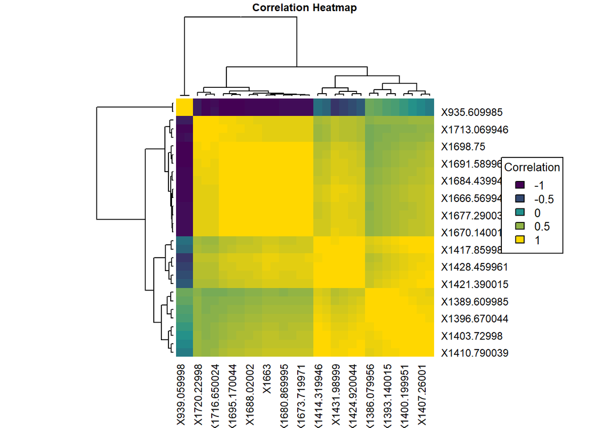

```r
# SMOTE Data
par(cex.main = 0.6)
corr <- cor(train_merged_smote[, -(n_features+1)])
# Create heat map
heatmap(corr, symm = TRUE,
        col = colorRampPalette(c("#440154", "#21908C", "gold"))(50),
        main = 'Correlation Heatmap',cex.main = 0.6)

# Add legend
legend("right",
       legend = seq(-1, 1, by = 0.5),  # Correlation range
       fill = colorRampPalette(c("#440154", "#21908C", "gold"))(5),
       title = "Correlation",
       cex = 0.8)
```

- The correlation heat maps reveal that some variables remain highly correlated. To address this issue and mitigate multicollinearity, we will employ Principal Component Analysis (PCA)

## PreProcess by PCA, Centering and Scaling Data

```r
# Imbalanced Data
pca_Preprocess <- preProcess(train_merged, method = c("center", "scale", "pca"))
train_mergedPreprocessed <- predict(pca_Preprocess, train_merged) # train data
test_mergedPreprocessed <- predict(pca_Preprocess,test_merged) # apply on test data

# SMOTE Data
pca_Preprocess_smote <- preProcess(train_merged_smote,method = c("center", "scale", "pca"))
train_merged_smote_Preprocessed <- predict(pca_Preprocess_smote,train_merged_smote)
test_merged_smote_Preprocessed <- predict(pca_Preprocess_smote,test_merged_smote)

# Check dimensions of the preprocessed data to ensure consistency

dim(train_mergedPreprocessed)
```

```
[1] 1055    4
```

```r
dim(test_mergedPreprocessed)
```

```
[1] 414   4
```

```r
dim(train_merged_smote_Preprocessed)
```

```
[1] 1872    3
```

```r
dim(test_merged_smote_Preprocessed)
```

```
[1] 414   3
```

## Train Models

- We will train models based on the reduced number of features.

```r
# Set random seed for reproducibility
set.seed (123)

# Set up the training control(10 folds 10 times cross_validation)
control <- trainControl(method = "repeatedcv", number = 10, repeats = 10,
                        classProbs = TRUE, savePredictions = "final",
                        summaryFunction = multiClassSummary,
                        selectionFunction = 'oneSE', allowParallel = TRUE)

# One SE rule will be used to select simplest yet optimal model within the 'best model'
```

```r
#Set the metric as accuracy
metric<-"Accuracy"
```

```r
# Hyperparameter Tuning
# We will use tuneLength to automatically determine the optimal parameters Cost (C) and  RBF kernel γ parameter
```

```r
#Register cluster for caret to train the models in parallel
cl<-makeCluster(6,type = "SOCK")
suppressWarnings(suppressMessages(
  registerDoSNOW(cl)))

# Start_time
start_time<-Sys.time()

#Train the model using cross-validation (10 folds, 10 times)
fit_svm_raw<-train(binary_class ~.,
                         data = train_mergedPreprocessed,
                         method = 'svmRadial', tuneLength = 10,
                         trControl = control,
                         metric = 'Accuracy') #unmodified data
#End_time
end_time<-Sys.time()

model_training_time<-end_time-start_time

stopCluster(cl) # Stop the parallel run cluster

print(model_training_time)
```

```
Time difference of 41.85265 secs
```

```r
#Register cluster for caret to train the models in parallel
cl<-makeCluster(6,type = "SOCK")
suppressWarnings(suppressMessages(
  registerDoSNOW(cl)))

# Start_time
start_time<-Sys.time()
fit_svm_smote_raw <- train(binary_class ~.,
                         data = train_merged_smote_Preprocessed,
                         method = 'svmRadial', tuneLength = 10,
                         trControl = control,
                         metric = 'Accuracy') # SMOTE data

#End_time
end_time<-Sys.time()

model_training_time<-end_time-start_time

stopCluster(cl) # Stop the parallel run cluster

print(model_training_time)
```

```
Time difference of 1.040729 mins
```

```r
# Display model results for imbalanced data
print(fit_svm_raw)
```

```
Support Vector Machines with Radial Basis Function Kernel

1055 samples
   3 predictor
   2 classes: 'adulterated', 'pure_arabica'

No pre-processing
Resampling: Cross-Validated (10 fold, repeated 10 times)
Summary of sample sizes: 949, 949, 949, 950, 949, 950, ...
Resampling results across tuning parameters:

  C       logLoss     AUC        prAUC      Accuracy   Kappa      F1
    0.25  0.09581132  0.9670723  0.7659864  0.9677815  0.5811460  0.9831817
    0.50  0.08984158  0.9669113  0.7679583  0.9680627  0.5730219  0.9833522
    1.00  0.08423817  0.9687193  0.7807967  0.9704401  0.5660955  0.9846590
    2.00  0.08228672  0.9696824  0.7893408  0.9724257  0.5869047  0.9857044
    4.00  0.07616682  0.9764732  0.7964516  0.9738435  0.6153832  0.9864298
    8.00  0.06380664  0.9879054  0.8097895  0.9762137  0.6586497  0.9876475
   16.00  0.05851940  0.9897667  0.8138649  0.9758354  0.6706396  0.9874181
   32.00  0.05769933  0.9894806  0.8119438  0.9764023  0.6949314  0.9876873
   64.00  0.06091943  0.9883961  0.8034497  0.9734688  0.6595537  0.9861479
  128.00  0.06444370  0.9872440  0.7916689  0.9710079  0.6206785  0.9848776
  Sensitivity  Specificity  Pos_Pred_Value  Neg_Pred_Value  Precision
  0.9876931    0.5510       0.9788628       0.7301828       0.9788628
  0.9885851    0.5375       0.9783076       0.7249278       0.9783076
  0.9934495    0.4895       0.9761159       0.8024050       0.9761159
  0.9953356    0.4930       0.9763288       0.8561809       0.9763288
  0.9951376    0.5275       0.9779465       0.8511190       0.9779465
  0.9953396    0.5755       0.9801519       0.8723333       0.9801519
  0.9930574    0.6150       0.9819435       0.8342381       0.9819435
  0.9915644    0.6600       0.9839348       0.8196729       0.9839348
  0.9896792    0.6355       0.9827588       0.7837949       0.9827588
  0.9895822    0.5840       0.9803338       0.7701299       0.9803338
  Recall     Detection_Rate  Balanced_Accuracy
  0.9876931  0.9427650       0.7693465
  0.9885851  0.9436168       0.7630426
  0.9934495  0.9482619       0.7414748
  0.9953356  0.9500607       0.7441678
  0.9951376  0.9498711       0.7613188
  0.9953396  0.9500634       0.7854198
  0.9930574  0.9478845       0.8040287
  0.9915644  0.9464586       0.8257822
  0.9896792  0.9446635       0.8125896
  0.9895822  0.9445683       0.7867911

Tuning parameter 'sigma' was held constant at a value of 0.4812847
Accuracy was used to select the optimal model using  the one SE rule.
The final values used for the model were sigma = 0.4812847 and C = 8.
```

```r
# Display results for data balanced by SMOTE
print(fit_svm_smote_raw)
```

```
Support Vector Machines with Radial Basis Function Kernel

1872 samples
   2 predictor
   2 classes: 'adulterated', 'pure_arabica'

No pre-processing
Resampling: Cross-Validated (10 fold, repeated 10 times)
Summary of sample sizes: 1685, 1684, 1685, 1685, 1685, 1685, ...
Resampling results across tuning parameters:

  C       logLoss     AUC        prAUC      Accuracy   Kappa      F1
    0.25  0.09089571  0.9852136  0.9713320  0.9764413  0.9527938  0.9752190
    0.50  0.08915788  0.9863650  0.9726641  0.9777773  0.9554702  0.9766169
    1.00  0.08961490  0.9861890  0.9722218  0.9774033  0.9547199  0.9762140
    2.00  0.09016258  0.9858693  0.9715140  0.9775097  0.9549294  0.9762859
    4.00  0.08800497  0.9865014  0.9714907  0.9768691  0.9536466  0.9756212
    8.00  0.08846401  0.9858895  0.9702964  0.9767607  0.9534265  0.9754773
   16.00  0.08672727  0.9855442  0.9708799  0.9773481  0.9546030  0.9760892
   32.00  0.08566267  0.9854725  0.9714980  0.9783087  0.9565292  0.9771155
   64.00  0.08443498  0.9861474  0.9726626  0.9791097  0.9581363  0.9779824
  128.00  0.08528072  0.9863199  0.9733917  0.9791100  0.9581367  0.9779799
  Sensitivity  Specificity  Pos_Pred_Value  Neg_Pred_Value  Precision
  0.9553643    0.9964583    0.9961944       0.9595253       0.9961944
  0.9565731    0.9979167    0.9977692       0.9606205       0.9977692
  0.9558051    0.9979167    0.9977617       0.9599493       0.9977617
  0.9547097    0.9991667    0.9991133       0.9590524       0.9991133
  0.9540504    0.9985417    0.9984282       0.9584316       0.9984282
  0.9529503    0.9993750    0.9993366       0.9575156       0.9993366
  0.9536073    0.9998958    0.9998913       0.9581169       0.9998913
  0.9554682    1.0000000    1.0000000       0.9597507       1.0000000
  0.9571118    1.0000000    1.0000000       0.9611711       1.0000000
  0.9571130    1.0000000    1.0000000       0.9611810       1.0000000
  Recall     Detection_Rate  Balanced_Accuracy
  0.9553643  0.4654338       0.9759113
  0.9565731  0.4660220       0.9772449
  0.9558051  0.4656480       0.9768609
  0.9547097  0.4651141       0.9769382
  0.9540504  0.4647932       0.9762960
  0.9529503  0.4642582       0.9761627
  0.9536073  0.4645785       0.9767515
  0.9554682  0.4654858       0.9777341
  0.9571118  0.4662868       0.9785559
  0.9571130  0.4662871       0.9785565

Tuning parameter 'sigma' was held constant at a value of 1.732932
Accuracy was used to select the optimal model using  the one SE rule.
The final values used for the model were sigma = 1.732932 and C = 32.
```

## Save the models for future use

```r
saveRDS(fit_svm_raw, "fit_svm_raw.rds")
saveRDS(fit_svm_smote_raw, "fit_svm_smote_raw.rds")
```

## Plot the cross-validation results —–> Model Selection

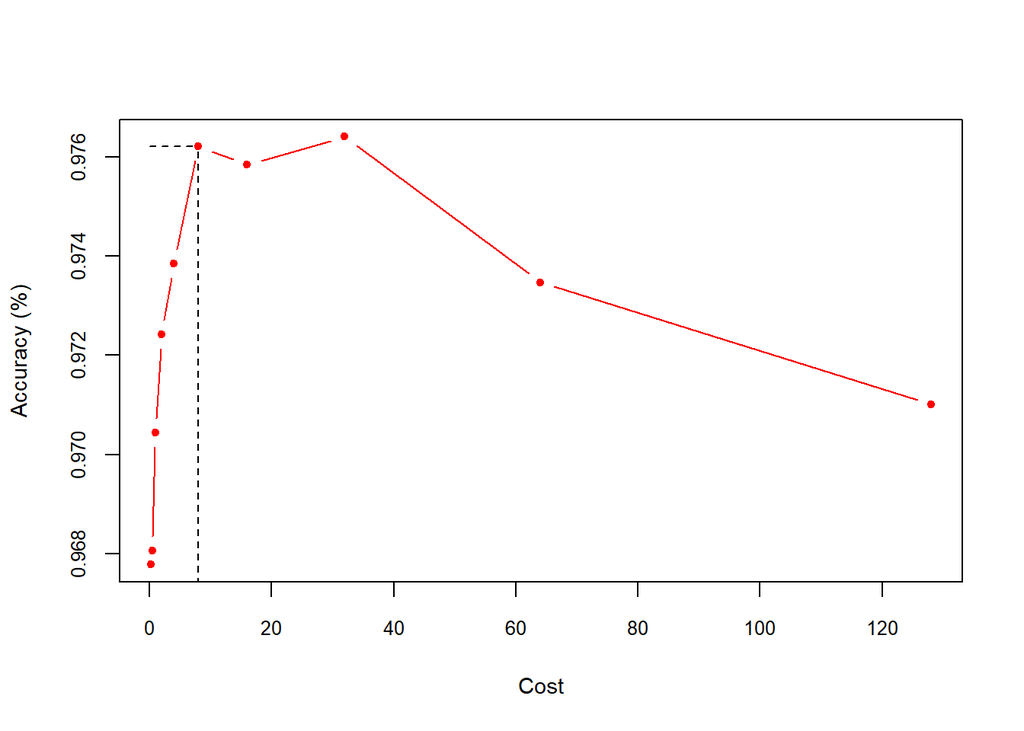

```r
# Imbalanced Data
C_data<-fit_svm_raw$results
best_C = fit_svm_raw$bestTune$C
y_Acc = C_data$Accuracy[C_data$C == best_C]
plot(C_data$C,C_data$Accuracy, type = "b",col = "red",pch = 20,cex.axis = 0.8,
     xlab = "Cost", ylab = "Accuracy (%)",cex.lab = 0.9)
# Add line from x-axis to the specific point
segments(x0 = best_C, y0 = 0, x1 = best_C, y1 = y_Acc, col = "black", lty = 2)

# Add line from y-axis to the specific point
segments(x0 = 0, y0 = y_Acc, x1 = best_C, y1 = y_Acc, col = "black", lty = 2)
```

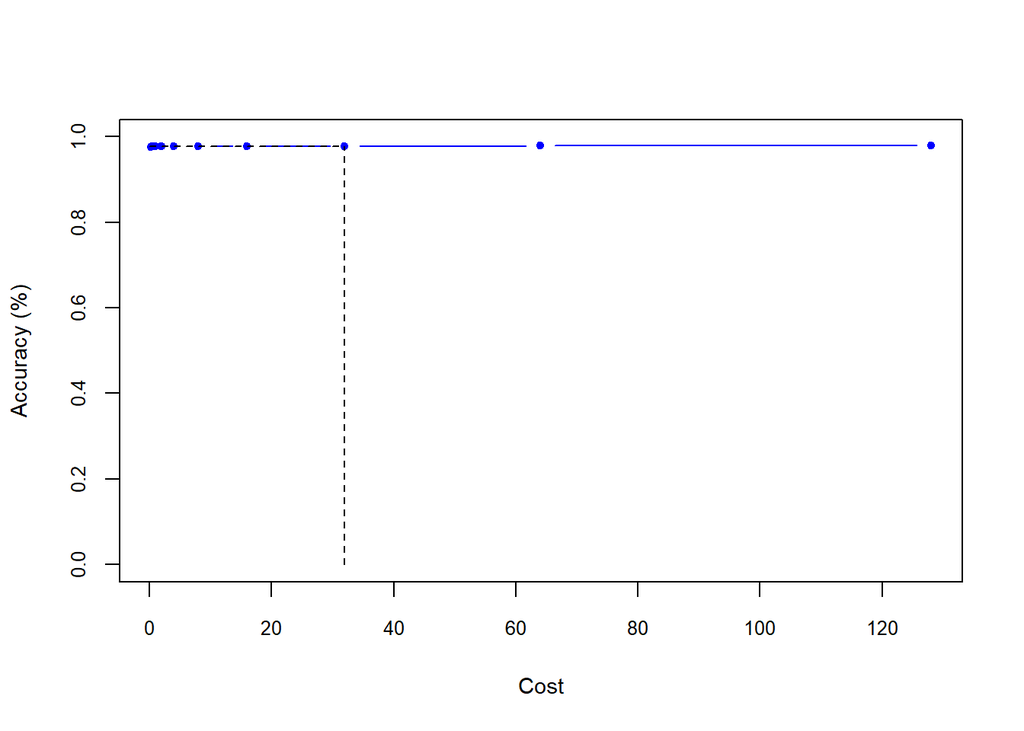

```r
# SMOTE Data
C_data<-fit_svm_smote_raw$results
best_C = fit_svm_smote_raw$bestTune$C
y_Acc = C_data$Accuracy[C_data$C == best_C]
plot(C_data$C,C_data$Accuracy, type = "b",col = "blue",pch = 20,cex.axis = 0.8,
     xlab = "Cost", ylab = "Accuracy (%)",cex.lab = 0.9,ylim = c(0,1))
# Add line from x-axis to the specific point
segments(x0 = best_C, y0 = 0, x1 = best_C, y1 = y_Acc, col = "black", lty = 2)

# Add line from y-axis to the specific point
segments(x0 = 0, y0 = y_Acc, x1 = best_C, y1 = y_Acc, col = "black", lty = 2)
```

## Display the cross-validation results

```r
print(paste('The optimal parametrers for training the SVM model are sigma value of', round(as.numeric(fit_svm_raw$bestTune$sigma),2), 'and Cost parameter of',
            fit_svm_raw$bestTune$C)) # unmodified data
```

```
[1] "The optimal parametrers for training the SVM model are sigma value of 0.48 and Cost parameter of 8"
```

```r
print(paste('The optimal parametrers for training the SVM model are sigma value of', round(as.numeric(fit_svm_raw$bestTune$sigma),2), 'and Cost parameter of',
            fit_svm_raw$bestTune$C)) # unmodified data
```

```
[1] "The optimal parametrers for training the SVM model are sigma value of 0.48 and Cost parameter of 8"
```

```r
print(paste('The optimal parametrers for training the SVM model are sigma value of', round(as.numeric(fit_svm_smote_raw$bestTune$sigma),2), 'and Cost parameter of',
            fit_svm_smote_raw$bestTune$C)) # SMOTE data
```

```
[1] "The optimal parametrers for training the SVM model are sigma value of 1.73 and Cost parameter of 32"
```

## Display CV Results in Tables

```r
kable(fit_svm_raw$results)
```

| sigma | C | logLoss | AUC | prAUC | Accuracy | Kappa | F1 | Sensitivity | Specificity | Pos_Pred_Value | Neg_Pred_Value | Precision | Recall | Detection_Rate | Balanced_Accuracy | logLossSD | AUCSD | prAUCSD | AccuracySD | KappaSD | F1SD | SensitivitySD | SpecificitySD | Pos_Pred_ValueSD | Neg_Pred_ValueSD | PrecisionSD | RecallSD | Detection_RateSD | Balanced_AccuracySD |
| --- | --- | --- | --- | --- | --- | --- | --- | --- | --- | --- | --- | --- | --- | --- | --- | --- | --- | --- | --- | --- | --- | --- | --- | --- | --- | --- | --- | --- | --- |
| 0.4812847 | 0.25 | 0.0958113 | 0.9670723 | 0.7659864 | 0.9677815 | 0.5811460 | 0.9831817 | 0.9876931 | 0.5510 | 0.9788628 | 0.7301828 | 0.9788628 | 0.9876931 | 0.9427650 | 0.7693465 | 0.0411657 | 0.0451262 | 0.0732896 | 0.0145048 | 0.1933444 | 0.0076363 | 0.0128571 | 0.2153198 | 0.0100857 | 0.2363578 | 0.0100857 | 0.0128571 | 0.0125671 | 0.1068452 |
| 0.4812847 | 0.50 | 0.0898416 | 0.9669113 | 0.7679583 | 0.9680627 | 0.5730219 | 0.9833522 | 0.9885851 | 0.5375 | 0.9783076 | 0.7249278 | 0.9783076 | 0.9885851 | 0.9436168 | 0.7630426 | 0.0341629 | 0.0446254 | 0.0759052 | 0.0131010 | 0.1967201 | 0.0068586 | 0.0111409 | 0.2185091 | 0.0101232 | 0.2278652 | 0.0101232 | 0.0111409 | 0.0109857 | 0.1083544 |
| 0.4812847 | 1.00 | 0.0842382 | 0.9687193 | 0.7807967 | 0.9704401 | 0.5660955 | 0.9846590 | 0.9934495 | 0.4895 | 0.9761159 | 0.8024050 | 0.9761159 | 0.9934495 | 0.9482619 | 0.7414748 | 0.0300805 | 0.0442226 | 0.0753637 | 0.0122043 | 0.2127787 | 0.0063210 | 0.0081300 | 0.2196525 | 0.0103132 | 0.2461035 | 0.0103132 | 0.0081300 | 0.0084756 | 0.1094951 |
| 0.4812847 | 2.00 | 0.0822867 | 0.9696824 | 0.7893408 | 0.9724257 | 0.5869047 | 0.9857044 | 0.9953356 | 0.4930 | 0.9763288 | 0.8561809 | 0.9763288 | 0.9953356 | 0.9500607 | 0.7441678 | 0.0289528 | 0.0428476 | 0.0749684 | 0.0121954 | 0.2094898 | 0.0063134 | 0.0072517 | 0.2097401 | 0.0098637 | 0.2197308 | 0.0098637 | 0.0072517 | 0.0075259 | 0.1050837 |
| 0.4812847 | 4.00 | 0.0761668 | 0.9764732 | 0.7964516 | 0.9738435 | 0.6153832 | 0.9864298 | 0.9951376 | 0.5275 | 0.9779465 | 0.8511190 | 0.9779465 | 0.9951376 | 0.9498711 | 0.7613188 | 0.0296470 | 0.0337771 | 0.0701525 | 0.0115130 | 0.2006601 | 0.0059552 | 0.0068324 | 0.2103838 | 0.0098360 | 0.2140473 | 0.0098360 | 0.0068324 | 0.0070745 | 0.1051779 |
| 0.4812847 | 8.00 | 0.0638066 | 0.9879054 | 0.8097895 | 0.9762137 | 0.6586497 | 0.9876475 | 0.9953396 | 0.5755 | 0.9801519 | 0.8723333 | 0.9801519 | 0.9953396 | 0.9500634 | 0.7854198 | 0.0262216 | 0.0127891 | 0.0625690 | 0.0111432 | 0.1884588 | 0.0057690 | 0.0069645 | 0.2091946 | 0.0098011 | 0.2044293 | 0.0098011 | 0.0069645 | 0.0071258 | 0.1043566 |
| 0.4812847 | 16.00 | 0.0585194 | 0.9897667 | 0.8138649 | 0.9758354 | 0.6706396 | 0.9874181 | 0.9930574 | 0.6150 | 0.9819435 | 0.8342381 | 0.9819435 | 0.9930574 | 0.9478845 | 0.8040287 | 0.0254572 | 0.0090015 | 0.0591923 | 0.0132098 | 0.2013454 | 0.0068820 | 0.0093936 | 0.2213937 | 0.0103271 | 0.2171604 | 0.0103271 | 0.0093936 | 0.0092838 | 0.1106156 |
| 0.4812847 | 32.00 | 0.0576993 | 0.9894806 | 0.8119438 | 0.9764023 | 0.6949314 | 0.9876873 | 0.9915644 | 0.6600 | 0.9839348 | 0.8196729 | 0.9839348 | 0.9915644 | 0.9464586 | 0.8257822 | 0.0237043 | 0.0095330 | 0.0625112 | 0.0132303 | 0.1828601 | 0.0069174 | 0.0096011 | 0.2097377 | 0.0098663 | 0.1889766 | 0.0098663 | 0.0096011 | 0.0093962 | 0.1049475 |
| 0.4812847 | 64.00 | 0.0609194 | 0.9883961 | 0.8034497 | 0.9734688 | 0.6595537 | 0.9861479 | 0.9896792 | 0.6355 | 0.9827588 | 0.7837949 | 0.9827588 | 0.9896792 | 0.9446635 | 0.8125896 | 0.0220576 | 0.0101445 | 0.0656150 | 0.0133899 | 0.1856354 | 0.0070110 | 0.0103539 | 0.2206848 | 0.0103898 | 0.1931070 | 0.0103898 | 0.0103539 | 0.0104970 | 0.1097960 |
| 0.4812847 | 128.00 | 0.0644437 | 0.9872440 | 0.7916689 | 0.9710079 | 0.6206785 | 0.9848776 | 0.9895822 | 0.5840 | 0.9803338 | 0.7701299 | 0.9803338 | 0.9895822 | 0.9445683 | 0.7867911 | 0.0235760 | 0.0102654 | 0.0670820 | 0.0132323 | 0.1819295 | 0.0069363 | 0.0106735 | 0.2087577 | 0.0098868 | 0.1996324 | 0.0098868 | 0.0106735 | 0.0105550 | 0.1038746 |

```r
kable(fit_svm_smote_raw$results)
```

| sigma | C | logLoss | AUC | prAUC | Accuracy | Kappa | F1 | Sensitivity | Specificity | Pos_Pred_Value | Neg_Pred_Value | Precision | Recall | Detection_Rate | Balanced_Accuracy | logLossSD | AUCSD | prAUCSD | AccuracySD | KappaSD | F1SD | SensitivitySD | SpecificitySD | Pos_Pred_ValueSD | Neg_Pred_ValueSD | PrecisionSD | RecallSD | Detection_RateSD | Balanced_AccuracySD |
| --- | --- | --- | --- | --- | --- | --- | --- | --- | --- | --- | --- | --- | --- | --- | --- | --- | --- | --- | --- | --- | --- | --- | --- | --- | --- | --- | --- | --- | --- |
| 1.732932 | 0.25 | 0.0908957 | 0.9852136 | 0.9713320 | 0.9764413 | 0.9527938 | 0.9752190 | 0.9553643 | 0.9964583 | 0.9961944 | 0.9595253 | 0.9961944 | 0.9553643 | 0.4654338 | 0.9759113 | 0.0331326 | 0.0097317 | 0.0124225 | 0.0098783 | 0.0198171 | 0.0106400 | 0.0201903 | 0.0068202 | 0.0072794 | 0.0174687 | 0.0072794 | 0.0201903 | 0.0099883 | 0.0101132 |
| 1.732932 | 0.50 | 0.0891579 | 0.9863650 | 0.9726641 | 0.9777773 | 0.9554702 | 0.9766169 | 0.9565731 | 0.9979167 | 0.9977692 | 0.9606205 | 0.9977692 | 0.9565731 | 0.4660220 | 0.9772449 | 0.0321500 | 0.0089430 | 0.0114547 | 0.0093276 | 0.0187155 | 0.0100750 | 0.0195585 | 0.0051288 | 0.0054327 | 0.0169268 | 0.0054327 | 0.0195585 | 0.0096518 | 0.0095734 |
| 1.732932 | 1.00 | 0.0896149 | 0.9861890 | 0.9722218 | 0.9774033 | 0.9547199 | 0.9762140 | 0.9558051 | 0.9979167 | 0.9977617 | 0.9599493 | 0.9977617 | 0.9558051 | 0.4656480 | 0.9768609 | 0.0320152 | 0.0086811 | 0.0113718 | 0.0097545 | 0.0195700 | 0.0105166 | 0.0198342 | 0.0055398 | 0.0058739 | 0.0172163 | 0.0058739 | 0.0198342 | 0.0097915 | 0.0099931 |
| 1.732932 | 2.00 | 0.0901626 | 0.9858693 | 0.9715140 | 0.9775097 | 0.9549294 | 0.9762859 | 0.9547097 | 0.9991667 | 0.9991133 | 0.9590524 | 0.9991133 | 0.9547097 | 0.4651141 | 0.9769382 | 0.0311479 | 0.0085926 | 0.0115333 | 0.0096494 | 0.0193642 | 0.0104560 | 0.0202689 | 0.0035286 | 0.0037514 | 0.0174980 | 0.0037514 | 0.0202689 | 0.0099863 | 0.0099138 |
| 1.732932 | 4.00 | 0.0880050 | 0.9865014 | 0.9714907 | 0.9768691 | 0.9536466 | 0.9756212 | 0.9540504 | 0.9985417 | 0.9984282 | 0.9584316 | 0.9984282 | 0.9540504 | 0.4647932 | 0.9762960 | 0.0297548 | 0.0085896 | 0.0121280 | 0.0098189 | 0.0197013 | 0.0106082 | 0.0198488 | 0.0046866 | 0.0050275 | 0.0171559 | 0.0050275 | 0.0198488 | 0.0098018 | 0.0100616 |
| 1.732932 | 8.00 | 0.0884640 | 0.9858895 | 0.9702964 | 0.9767607 | 0.9534265 | 0.9754773 | 0.9529503 | 0.9993750 | 0.9993366 | 0.9575156 | 0.9993366 | 0.9529503 | 0.4642582 | 0.9761627 | 0.0290773 | 0.0092011 | 0.0136033 | 0.0093818 | 0.0188287 | 0.0101793 | 0.0198313 | 0.0028937 | 0.0030505 | 0.0171074 | 0.0030505 | 0.0198313 | 0.0098366 | 0.0096470 |
| 1.732932 | 16.00 | 0.0867273 | 0.9855442 | 0.9708799 | 0.9773481 | 0.9546030 | 0.9760892 | 0.9536073 | 0.9998958 | 0.9998913 | 0.9581169 | 0.9998913 | 0.9536073 | 0.4645785 | 0.9767515 | 0.0292184 | 0.0101944 | 0.0145335 | 0.0097930 | 0.0196493 | 0.0105792 | 0.0202811 | 0.0010417 | 0.0010870 | 0.0175961 | 0.0010870 | 0.0202811 | 0.0100655 | 0.0100615 |
| 1.732932 | 32.00 | 0.0856627 | 0.9854725 | 0.9714980 | 0.9783087 | 0.9565292 | 0.9771155 | 0.9554682 | 1.0000000 | 1.0000000 | 0.9597507 | 1.0000000 | 0.9554682 | 0.4654858 | 0.9777341 | 0.0292719 | 0.0101282 | 0.0138541 | 0.0099598 | 0.0199850 | 0.0107704 | 0.0204603 | 0.0000000 | 0.0000000 | 0.0177148 | 0.0000000 | 0.0204603 | 0.0101880 | 0.0102302 |
| 1.732932 | 64.00 | 0.0844350 | 0.9861474 | 0.9726626 | 0.9791097 | 0.9581363 | 0.9779824 | 0.9571118 | 1.0000000 | 1.0000000 | 0.9611711 | 1.0000000 | 0.9571118 | 0.4662868 | 0.9785559 | 0.0288936 | 0.0096804 | 0.0126009 | 0.0096159 | 0.0192921 | 0.0103635 | 0.0197581 | 0.0000000 | 0.0000000 | 0.0171979 | 0.0000000 | 0.0197581 | 0.0098668 | 0.0098791 |
| 1.732932 | 128.00 | 0.0852807 | 0.9863199 | 0.9733917 | 0.9791100 | 0.9581367 | 0.9779799 | 0.9571130 | 1.0000000 | 1.0000000 | 0.9611810 | 1.0000000 | 0.9571130 | 0.4662871 | 0.9785565 | 0.0291708 | 0.0094342 | 0.0115752 | 0.0097648 | 0.0195902 | 0.0105178 | 0.0200637 | 0.0000000 | 0.0000000 | 0.0174833 | 0.0000000 | 0.0200637 | 0.0099972 | 0.0100319 |

```r
# Select row for the optimal model
# Imbalanced Data
# Select the best results row # unmodified data
selected_row <- fit_svm_raw$results %>%
  filter(C==fit_svm_raw$bestTune$C & sigma == fit_svm_raw$bestTune$sigma)

kable(selected_row)
```

| sigma | C | logLoss | AUC | prAUC | Accuracy | Kappa | F1 | Sensitivity | Specificity | Pos_Pred_Value | Neg_Pred_Value | Precision | Recall | Detection_Rate | Balanced_Accuracy | logLossSD | AUCSD | prAUCSD | AccuracySD | KappaSD | F1SD | SensitivitySD | SpecificitySD | Pos_Pred_ValueSD | Neg_Pred_ValueSD | PrecisionSD | RecallSD | Detection_RateSD | Balanced_AccuracySD |
| --- | --- | --- | --- | --- | --- | --- | --- | --- | --- | --- | --- | --- | --- | --- | --- | --- | --- | --- | --- | --- | --- | --- | --- | --- | --- | --- | --- | --- | --- |
| 0.4812847 | 8 | 0.0638066 | 0.9879054 | 0.8097895 | 0.9762137 | 0.6586497 | 0.9876475 | 0.9953396 | 0.5755 | 0.9801519 | 0.8723333 | 0.9801519 | 0.9953396 | 0.9500634 | 0.7854198 | 0.0262216 | 0.0127891 | 0.062569 | 0.0111432 | 0.1884588 | 0.005769 | 0.0069645 | 0.2091946 | 0.0098011 | 0.2044293 | 0.0098011 | 0.0069645 | 0.0071258 | 0.1043566 |

```r
# Select row for the optimal model
# Select the best results row
selected_row <- fit_svm_smote_raw$results %>%
  filter(C==fit_svm_smote_raw$bestTune$C &
           sigma == fit_svm_smote_raw$bestTune$sigma)

kable(selected_row)
```

| sigma | C | logLoss | AUC | prAUC | Accuracy | Kappa | F1 | Sensitivity | Specificity | Pos_Pred_Value | Neg_Pred_Value | Precision | Recall | Detection_Rate | Balanced_Accuracy | logLossSD | AUCSD | prAUCSD | AccuracySD | KappaSD | F1SD | SensitivitySD | SpecificitySD | Pos_Pred_ValueSD | Neg_Pred_ValueSD | PrecisionSD | RecallSD | Detection_RateSD | Balanced_AccuracySD |
| --- | --- | --- | --- | --- | --- | --- | --- | --- | --- | --- | --- | --- | --- | --- | --- | --- | --- | --- | --- | --- | --- | --- | --- | --- | --- | --- | --- | --- | --- |
| 1.732932 | 32 | 0.0856627 | 0.9854725 | 0.971498 | 0.9783087 | 0.9565292 | 0.9771155 | 0.9554682 | 1 | 1 | 0.9597507 | 1 | 0.9554682 | 0.4654858 | 0.9777341 | 0.0292719 | 0.0101282 | 0.0138541 | 0.0099598 | 0.019985 | 0.0107704 | 0.0204603 | 0 | 0 | 0.0177148 | 0 | 0.0204603 | 0.010188 | 0.0102302 |

## Confusion matrix for the training data

```r
confusionMatrix(fit_svm_raw$pred$pred,
                fit_svm_raw$pred$obs) # unmodified data
```

```
Confusion Matrix and Statistics

              Reference
Prediction     adulterated pure_arabica
  adulterated        10023          204
  pure_arabica          47          276

               Accuracy : 0.9762
                 95% CI : (0.9731, 0.979)
    No Information Rate : 0.9545
    P-Value [Acc > NIR] : < 2.2e-16

                  Kappa : 0.6755

 Mcnemar's Test P-Value : < 2.2e-16

            Sensitivity : 0.9953
            Specificity : 0.5750
         Pos Pred Value : 0.9801
         Neg Pred Value : 0.8545
             Prevalence : 0.9545
         Detection Rate : 0.9500
   Detection Prevalence : 0.9694
      Balanced Accuracy : 0.7852

       'Positive' Class : adulterated
```

```r
confusionMatrix(fit_svm_smote_raw$pred$pred,
                fit_svm_smote_raw$pred$obs) # SMOTE data
```

```
Confusion Matrix and Statistics

              Reference
Prediction     adulterated pure_arabica
  adulterated         8714            0
  pure_arabica         406         9600

               Accuracy : 0.9783
                 95% CI : (0.9761, 0.9804)
    No Information Rate : 0.5128
    P-Value [Acc > NIR] : < 2.2e-16

                  Kappa : 0.9565

 Mcnemar's Test P-Value : < 2.2e-16

            Sensitivity : 0.9555
            Specificity : 1.0000
         Pos Pred Value : 1.0000
         Neg Pred Value : 0.9594
             Prevalence : 0.4872
         Detection Rate : 0.4655
   Detection Prevalence : 0.4655
      Balanced Accuracy : 0.9777

       'Positive' Class : adulterated
```

## Test the model performance on test data for unbalanced trained data

```r
# Predict on the test set

test_svm_unmodified <- predict(fit_svm_raw,newdata=test_mergedPreprocessed)

# Get the confusion matrix
test_svm_unmodified_CMtrx <- confusionMatrix(test_svm_unmodified,
                                             test_mergedPreprocessed$binary_class)
test_svm_unmodified_CMtrx
```

```
Confusion Matrix and Statistics

              Reference
Prediction     adulterated pure_arabica
  adulterated          385           19
  pure_arabica           2            8

               Accuracy : 0.9493
                 95% CI : (0.9235, 0.9683)
    No Information Rate : 0.9348
    P-Value [Acc > NIR] : 0.1351295

                  Kappa : 0.4117

 Mcnemar's Test P-Value : 0.0004803

            Sensitivity : 0.9948
            Specificity : 0.2963
         Pos Pred Value : 0.9530
         Neg Pred Value : 0.8000
             Prevalence : 0.9348
         Detection Rate : 0.9300
   Detection Prevalence : 0.9758
      Balanced Accuracy : 0.6456

       'Positive' Class : adulterated
```

```r
kable(test_svm_unmodified_CMtrx$byClass)
```

|  | x |
| --- | --- |
| Sensitivity | 0.9948320 |
| Specificity | 0.2962963 |
| Pos Pred Value | 0.9529703 |
| Neg Pred Value | 0.8000000 |
| Precision | 0.9529703 |
| Recall | 0.9948320 |
| F1 | 0.9734513 |
| Prevalence | 0.9347826 |
| Detection Rate | 0.9299517 |
| Detection Prevalence | 0.9758454 |
| Balanced Accuracy | 0.6455642 |

```r
#View the results as knitr table
kable(test_svm_unmodified_CMtrx$table)
```

|  | adulterated | pure_arabica |
| --- | --- | --- |
| adulterated | 385 | 19 |
| pure_arabica | 2 | 8 |

```r
# Calculate the Matthews Correlation coefficient

# Extracting the components of the confusion matrix
cf_table_svm <- test_svm_unmodified_CMtrx$table
TP <- cf_table_svm[1,1]
TN <- cf_table_svm[2,2]
FP <- cf_table_svm[2,1]
FN <- cf_table_svm[1,2]

# Calculating MCC
MCC <- (TP * TN - FP * FN) / sqrt((TP + FP) * (TP + FN) * (TN + FP) * (TN + FN))

# Printing the MCC value
print(paste("The MCC value is for the model",MCC))
```

```
[1] "The MCC value is for the model 0.468199733945384"
```

## Test the model performance on test data using SMOTE trained model

```r
# Predict on the test set

test_svm_smote <- predict(fit_svm_smote_raw,
                          newdata=test_merged_smote_Preprocessed)

# Get the confusion matrix
test_svm_smote_CMtrx <- confusionMatrix(test_svm_smote,
                                             test_merged_smote_Preprocessed$binary_class)
test_svm_smote_CMtrx
```

```
Confusion Matrix and Statistics

              Reference
Prediction     adulterated pure_arabica
  adulterated          371            6
  pure_arabica          16           21

               Accuracy : 0.9469
                 95% CI : (0.9206, 0.9664)
    No Information Rate : 0.9348
    P-Value [Acc > NIR] : 0.18655

                  Kappa : 0.6282

 Mcnemar's Test P-Value : 0.05501

            Sensitivity : 0.9587
            Specificity : 0.7778
         Pos Pred Value : 0.9841
         Neg Pred Value : 0.5676
             Prevalence : 0.9348
         Detection Rate : 0.8961
   Detection Prevalence : 0.9106
      Balanced Accuracy : 0.8682

       'Positive' Class : adulterated
```

```r
kable(test_svm_smote_CMtrx$byClass)
```

|  | x |
| --- | --- |
| Sensitivity | 0.9586563 |
| Specificity | 0.7777778 |
| Pos Pred Value | 0.9840849 |
| Neg Pred Value | 0.5675676 |
| Precision | 0.9840849 |
| Recall | 0.9586563 |
| F1 | 0.9712042 |
| Prevalence | 0.9347826 |
| Detection Rate | 0.8961353 |
| Detection Prevalence | 0.9106280 |
| Balanced Accuracy | 0.8682171 |

```r
# Calculate the Matthews Correlation coefficient: SMOTE Data

# Extracting the components of the confusion matrix
cf_table_svm_smote <- test_svm_smote_CMtrx$table
TP <- cf_table_svm_smote[1,1]
TN <- cf_table_svm_smote[2,2]
FP <- cf_table_svm_smote[2,1]
FN <- cf_table_svm_smote[1,2]

# Calculating MCC
MCC <- (TP * TN - FP * FN) / sqrt((TP + FP) * (TP + FN) * (TN + FP) * (TN + FN))

# Printing the MCC value
print(paste("The MCC value is for the model",MCC))
```

```
[1] "The MCC value is for the model 0.637381894087092"
```

```r
# Compare model performance
results <- resamples(list(svm = fit_svm_raw, svm_smote = fit_svm_smote_raw))

# Print summary of re-sampling results
resample_summary <- summary(results)$statistics

# Convert re-sampling statistics to a data frame
resample_df <- do.call(rbind, lapply(resample_summary, function(x) x[, "Mean", drop = FALSE]))

# Create a neat table
kable(resample_df, caption = "Model Performance Metrics")
```

Model Performance Metrics

|  | Mean |
| --- | --- |
| svm | 0.9762137 |
| svm_smote | 0.9783087 |
| svm | 0.9879054 |
| svm_smote | 0.9854725 |
| svm | 0.7854198 |
| svm_smote | 0.9777341 |
| svm | 0.9500634 |
| svm_smote | 0.4654858 |
| svm | 0.9876475 |
| svm_smote | 0.9771155 |
| svm | 0.6586497 |
| svm_smote | 0.9565292 |
| svm | 0.0638066 |
| svm_smote | 0.0856627 |
| svm | 0.8723333 |
| svm_smote | 0.9597507 |
| svm | 0.9801519 |
| svm_smote | 1.0000000 |
| svm | 0.8097895 |
| svm_smote | 0.9714980 |
| svm | 0.9801519 |
| svm_smote | 1.0000000 |
| svm | 0.9953396 |
| svm_smote | 0.9554682 |
| svm | 0.9953396 |
| svm_smote | 0.9554682 |
| svm | 0.5755000 |
| svm_smote | 1.0000000 |

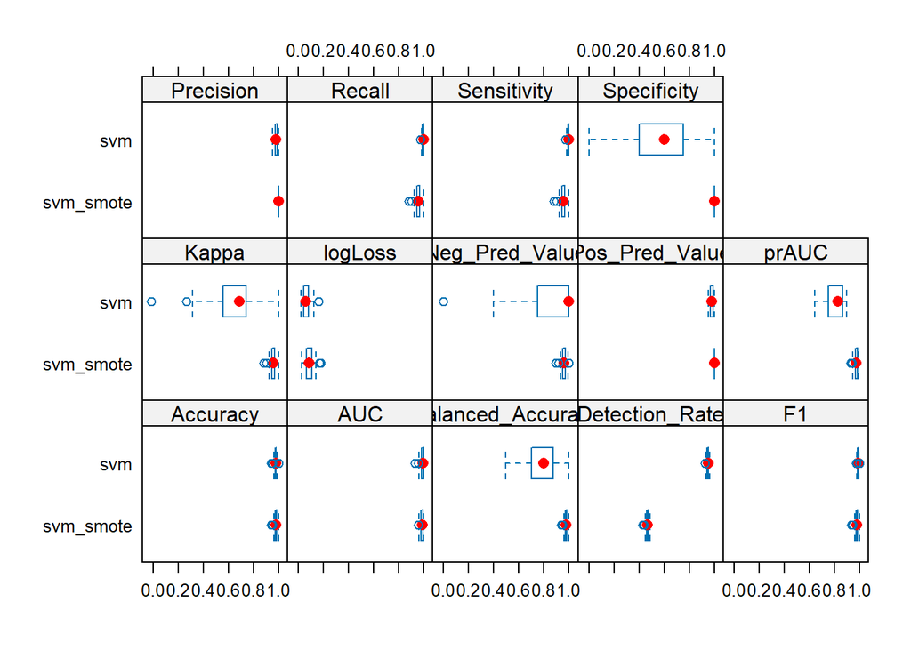

```r
# Boxplot for accuracy comparison
bwplot(results, col = 'red')
```

```r
# Pairwise comparisons
model_differences <- diff(results)
model_differences$statistics
```

```
$Accuracy
$Accuracy$svm.diff.svm_smote

    One Sample t-test

data:  x
t = -1.5174, df = 99, p-value = 0.1323
alternative hypothesis: true mean is not equal to 0
95 percent confidence interval:
 -0.0048344468  0.0006444461
sample estimates:
mean of x
-0.002095



$AUC
$AUC$svm.diff.svm_smote

    One Sample t-test

data:  x
t = 1.6157, df = 99, p-value = 0.1093
alternative hypothesis: true mean is not equal to 0
95 percent confidence interval:
 -0.0005549537  0.0054208053
sample estimates:
  mean of x
0.002432926



$Balanced_Accuracy
$Balanced_Accuracy$svm.diff.svm_smote

    One Sample t-test

data:  x
t = -18.605, df = 99, p-value < 2.2e-16
alternative hypothesis: true mean is not equal to 0
```

[output cut: 166 more lines]

```


$Specificity
$Specificity$svm.diff.svm_smote

    One Sample t-test

data:  x
t = -20.292, df = 99, p-value < 2.2e-16
alternative hypothesis: true mean is not equal to 0
95 percent confidence interval:
 -0.4660087 -0.3829913
sample estimates:
mean of x
  -0.4245
```

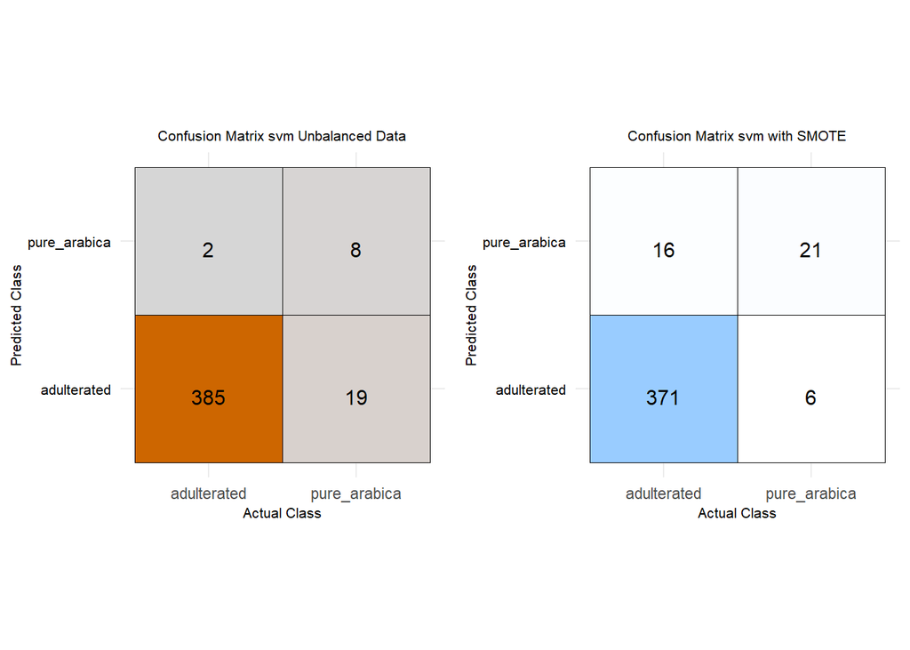

```r
p1<-ggplot(data = as.data.frame(test_svm_unmodified_CMtrx$table), aes(x = Reference, y = Prediction)) +
  geom_tile(aes(fill = Freq), color = "black") +
  geom_text(aes(label = sprintf("%0.0f", Freq)), vjust = 1,color = "black",size = 4) +
  scale_fill_gradient(low = "gray84", high = "darkorange3", name = "Frequency") +
  theme_minimal() +
  labs(x = "Actual Class", y = "Predicted Class", color = 'black',title = 'Confusion Matrix svm Unbalanced Data')+
  theme(
    legend.position =  "none",
    axis.text.y = element_text(color = "black",size = 8),
    axis.title.x  = element_text(size = 8),
    axis.title.y = element_text(size = 8),aspect.ratio = 1,
    plot.title = element_text(size = 8,hjust = 0.5))


p2<-ggplot(data = as.data.frame(test_svm_smote_CMtrx$table), aes(x = Reference, y = Prediction)) +
  geom_tile(aes(fill = Freq), color = "black") +
  geom_text(aes(label = sprintf("%0.0f", Freq)), vjust = 1,color = "black",size = 4) +
  scale_fill_gradient(low = "white", high = "#99ccff", name = "Frequency") +
  theme_minimal() +
  labs(x = "Actual Class", y = "Predicted Class", color = 'black',title = 'Confusion Matrix svm with SMOTE')+
  theme(
    legend.position =  "none",
    axis.text.y = element_text(color = "black",size = 8),
    axis.title.x  = element_text(size = 8),
    axis.title.y = element_text(size = 8),aspect.ratio = 1,
    plot.title = element_text(size = 8,hjust = 0.5))

grid.arrange(p1,p2, nrow =1)
```

## ROC Curve

```r
#SMOTE data

# Generate the ROC curve
roc_curve <- roc(test_merged_smote_Preprocessed$binary_class,
                 as.numeric(test_svm_smote),
                 levels = c("adulterated", "pure_arabica"),
                 positive = 'adulterated')
```

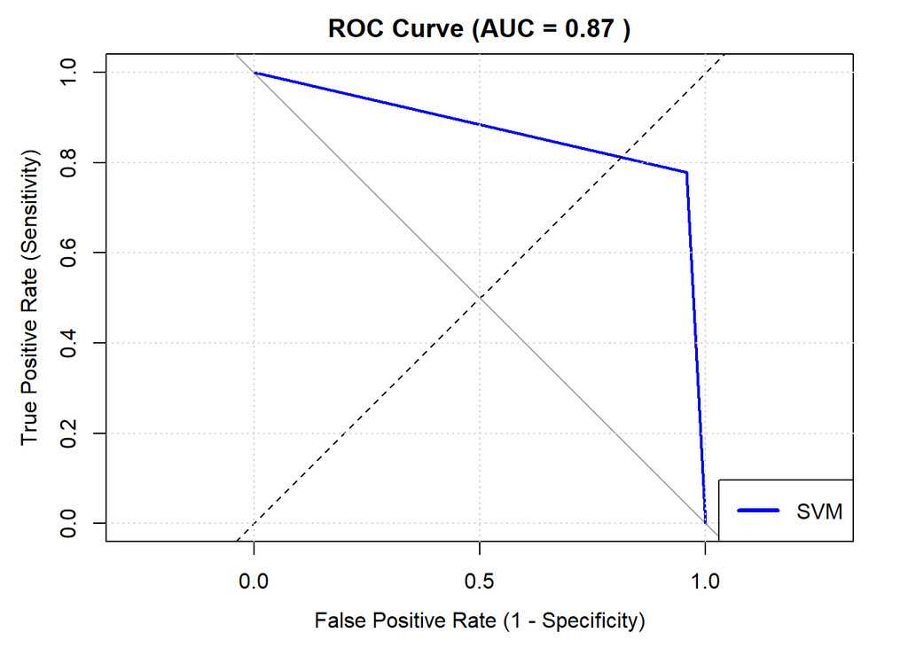

```r
# Calculate the AUC
auc_value <- auc(roc_curve)

# Plot the ROC curve
plot(roc_curve, col = 'blue', lwd = 2,
     main = paste("ROC Curve (AUC =", round(auc_value, 2), ")"),
     xlab = "False Positive Rate (1 - Specificity)",
     ylab = "True Positive Rate (Sensitivity)",
     xlim = c(0, 1), ylim = c(0, 1))
abline(a = 0, b = 1, lty = 2, col = "black")
grid(nx = NULL, ny = NULL, col = "lightgray", lty = "dotted")
legend("bottomright", legend = c("SVM"), col = 'blue', lwd = 3)
```

## Conclusion

- Boruta algorithm for variable selection from raw spectra and SVM show relatively better but lower performance as compared to models built with spectral preprocessed data.